# 20_modeles_occupation

Léa Bouchet

2024-04-08

# Modèles d’occupation

On souhaite ici appliquer le package “spOccupancy”: On souhaite structurer notre jeu de données de la même manière afin de pouvoir réaliser les mêmes analyses avec nos données ASPE Bretagne.La première étape est de transformer le jeu de données en détection / non détection (présence / absence d’un espèce : TRUE / FALSE) sur un site donné. Le premier modèle tester est un modèle d’occupation d’une seule espèce (donc à l’espèce).

## Installation

### Chargement des packages, fonctions et des données

```r
## Chargement des packages ----
library(ggthemes)
library(tidyverse)
```

```r
library(aspe)
library(ggplot2)
library (khroma)
library(dplyr)
library(wesanderson)
library(zoo)
library(lemon)
library(trend)
library(ggh4x)
library(spOccupancy)
library(coda)
library(stars)
## Chargement des sauvegardes ----
load(file = "../processed_data/selection_pop_ope.rda")
load(file = "../processed_data/pre_traitements_donnees_env.rda")
load(file = "../processed_data/assemblage_tab_par_ope.rda")
load(file = "../processed_data/analyse_selection_especes.rda")
```

```r
# Définition des couleurs de l'OFB en format RGB
pal <- c("#007844", "#92D050", "#0087C1", "#FCEE21", "#00AEEF", "#1D1D1B", "#A97B30", "#B9D9EB")
```

# Constitution du jeu de données

On souhaite transformer notre jeu de données en ABSENCE / PRESENCE : où absence = 0 et présence = 1 : Réalisation pour le Brochet (BRO) dans un premier temps: “Extract Detection-nondetection Data”

```r
mon_espece <- "BRO"
```

```r
ope_ind <- ope_indicateur %>%
  filter(indicateur == "densite_surface") %>%
  select (ope_id,
          esp_code_alternatif
           ) %>%
  unique() %>%
  mutate (presence = 1)


mes_combinaisons <- expand.grid(ope_ind$ope_id, ope_ind$esp_code_alternatif) %>%
  distinct() %>%
  rename(ope_id = Var1,
         esp_code_alternatif = Var2)
```

```r
y <- mes_combinaisons %>%
  left_join(y = ope_ind) %>%
  mutate(presence = ifelse(is.na(presence), 0, presence)) %>%
  left_join(y = ope_selection %>%
              select(ope_id,
                     pop_id,
                     annee
                    # ope_date
                     )) %>%
              select(-ope_id) %>%
              distinct() %>%
#  mutate(annee = paste0("a_", annee)) %>%
  filter(esp_code_alternatif == mon_espece) %>%
  select(-esp_code_alternatif) %>%
  arrange(annee) %>%
  pivot_wider(names_from = annee,
              values_from = presence) %>%
  arrange(pop_id)
```

## Covariables d’occurrence :

```r
occ.covs <- ope_selection_param_env %>%
  group_by(pop_id, parametre) %>%
  summarise(valeur = median(valeur, na.rm = TRUE)) %>%
  ungroup() %>%
  mutate(valeur = log10(valeur)) %>%
  pivot_wider(names_from = parametre,
              values_from = valeur) %>%
  arrange(pop_id)
test <- ope_selection %>%
  mutate(jour = lubridate::yday(ope_date)) %>%
  mutate(protocole = as.factor(pro_libelle),
         protocole = as.integer(protocole)) %>%
  select(pop_id,
         annee,
         jour,
         protocole)

jour <- test %>%
  select(-protocole) %>%
  arrange(annee) %>%
  pivot_wider(names_from = annee,
              values_from = jour) %>%
  arrange(pop_id)

protocole <- test %>%
  select(-jour) %>%
  arrange(annee) %>%
  pivot_wider(names_from = annee,
              values_from = protocole) %>%
  arrange(pop_id)

modele_bro <- list()
```

```r
modele_bro$y <- y
modele_bro$occ.covs <- occ.covs
modele_bro$det.covs$jour <- jour
modele_bro$det.covs$protocole <- protocole
```

```r
bro.occ.formula <- ~ scale(profondeur) + scale(pente) + scale(temp_juillet)
bro.det.formula <- ~ scale(jour) + scale(protocole) + I(scale(jour)^2)
```

```r
bro.inits <- list(alpha = 0,
                   beta = 0,
                   z = apply(modele_bro$y, 1, max, na.rm = TRUE))
```

```r
bro.priors <- list(alpha.normal = list(mean = 0, var = 2.72),
                    beta.normal = list(mean = 0, var = 2.72))
```

```r
n.samples <- 5000
n.burn <- 3000
n.thin <- 2
n.chains <- 3
```

```r
out <- PGOcc(occ.formula = bro.occ.formula,
             det.formula = bro.det.formula,
             data = modele_bro,
             inits = bro.inits,
             n.samples = n.samples,
             priors = bro.priors,
             n.omp.threads = 1,
             verbose = TRUE,
             n.report = 1000,
             n.burn = n.burn,
             n.thin = n.thin,
             n.chains = n.chains)
```

[output not shown]

Représentation visuelle des résultats : Pour ‘beta’ :

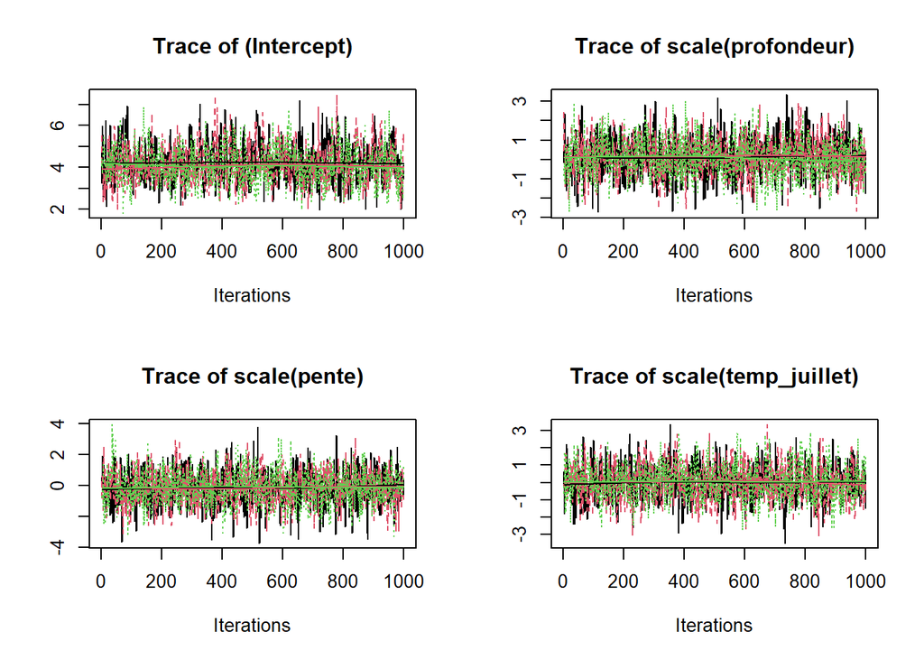

```r
plot(out, 'beta', density = FALSE) # Occupancy parameters.
```

Pour ‘alpha’ :

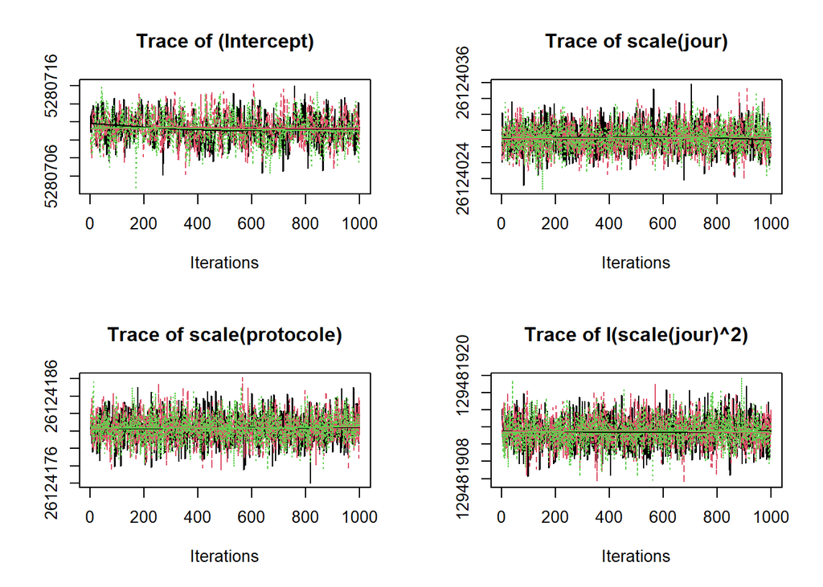

```r
plot(out, 'alpha', density = FALSE) # Detection parameters.
```

# Sauvegarde

```r
save(ope_indicateur,
     modele_bro,
     file = "../processed_data/modeles_occupation.rda")
```